# Project: WeRateDogs data improvement

- Introduction
- Data Wrangling
- Gathering
- Assessing
- Cleaning
- Storing
- Exploratory Data Analysis
- Conclusions
- References

## Introduction

This document details the series of actions carried out with the goal of improving the quality of the dataset from the Twitter user 'WeRateDogs'. This peculiar dataset holds interesting information of dogs featured on the internet. In order to make this analysis and others easier, this dataset was augmented, assessed, cleaned and briefly analyzed. The file contains observations that could be useful to get insights on which dogs seem to attract more attention, what pictures or actions are the most popular over twitter and so on.

```python
#Required packages and tools are imported
import pandas as pd
import numpy as np
import requests as rd
import time
import tweepy as tw
import json
import sys
from matplotlib import pyplot as plt
%matplotlib inline
```

```python
#Twitter API credentials
#consumer_key = 'YOUR CONSUMER KEY'
#consumer_secret = 'YOUR CONSUMER SECRET'
#access_token = 'YOUR ACCESS TOKEN'
#access_secret = 'YOUR ACCESS SECRET'

#auth = tw.OAuthHandler(consumer_key, consumer_secret)
#auth.set_access_token(access_token, access_token_secret)
#api = tw.API(auth, wait_on_rate_limit=True, wait_on_rate_limit_notify = True, parser=tw.parsers.JSONParser())
```

## Data Wrangling

This section holds the steps carried out to assemble/obtain, inspect and properly clean the datasets. All steps will be documented, and more information can be obtained in the attached file called ‘wrangle_report.pdf’.

### Gathering

```python
# Read CSV (comma-separated) file into DataFrame
twitter_archive = pd.read_csv('twitter-archive-enhanced.csv')
```

> The dataset is first inspected to make sure it was imported successfully

```python
# Preliminary Visual inspection of the dataset
twitter_archive.head()
```

|  | tweet_id | in_reply_to_status_id | in_reply_to_user_id | timestamp | source | text | retweeted_status_id | retweeted_status_user_id | retweeted_status_timestamp | expanded_urls | rating_numerator | rating_denominator | name | doggo | floofer | pupper | puppo |
| --- | --- | --- | --- | --- | --- | --- | --- | --- | --- | --- | --- | --- | --- | --- | --- | --- | --- |
| 0 | 892420643555336193 | NaN | NaN | 2017-08-01 16:23:56 +0000 | <a href="http://twitter.com/download/iphone" r... | This is Phineas. He's a mystical boy. Only eve... | NaN | NaN | NaN | https://twitter.com/dog_rates/status/892420643... | 13 | 10 | Phineas | None | None | None | None |
| 1 | 892177421306343426 | NaN | NaN | 2017-08-01 00:17:27 +0000 | <a href="http://twitter.com/download/iphone" r... | This is Tilly. She's just checking pup on you.... | NaN | NaN | NaN | https://twitter.com/dog_rates/status/892177421... | 13 | 10 | Tilly | None | None | None | None |
| 2 | 891815181378084864 | NaN | NaN | 2017-07-31 00:18:03 +0000 | <a href="http://twitter.com/download/iphone" r... | This is Archie. He is a rare Norwegian Pouncin... | NaN | NaN | NaN | https://twitter.com/dog_rates/status/891815181... | 12 | 10 | Archie | None | None | None | None |
| 3 | 891689557279858688 | NaN | NaN | 2017-07-30 15:58:51 +0000 | <a href="http://twitter.com/download/iphone" r... | This is Darla. She commenced a snooze mid meal... | NaN | NaN | NaN | https://twitter.com/dog_rates/status/891689557... | 13 | 10 | Darla | None | None | None | None |
| 4 | 891327558926688256 | NaN | NaN | 2017-07-29 16:00:24 +0000 | <a href="http://twitter.com/download/iphone" r... | This is Franklin. He would like you to stop ca... | NaN | NaN | NaN | https://twitter.com/dog_rates/status/891327558... | 12 | 10 | Franklin | None | None | None | None |

> As this importation seemed to have been successful, the second dataset will be downloaded from the URL provided using the library *requests* :

```python
# Create a variable holding the URL with the files and same for the response
URL1 = 'https://d17h27t6h515a5.cloudfront.net/topher/2017/August/599fd2ad_image-predictions/image-predictions.tsv'
response = rd.get(URL1)

# Create the file where the content of the url will be saved
with open ('image_predictions.tsv', mode = 'wb') as file:
    file.write(response.content)
```

```python
# Read TSV (Tab-separated) file into DataFrame
image_predictions = pd.read_csv('image_predictions.tsv', sep='\t')
```

```python
# Preliminary visual inspection of the dataset
image_predictions.sample(2)
```

|  | tweet_id | jpg_url | img_num | p1 | p1_conf | p1_dog | p2 | p2_conf | p2_dog | p3 | p3_conf | p3_dog |
| --- | --- | --- | --- | --- | --- | --- | --- | --- | --- | --- | --- | --- |
| 569 | 678389028614488064 | https://pbs.twimg.com/media/CWofOHUWUAACGVa.jpg | 1 | miniature_pinscher | 0.516284 | True | kelpie | 0.227402 | True | vizsla | 0.103246 | True |
| 295 | 671357843010908160 | https://pbs.twimg.com/media/CVEkZaPXIAEw5vr.jpg | 1 | Italian_greyhound | 0.831757 | True | toy_terrier | 0.043306 | True | Chihuahua | 0.036773 | True |

> The third dataset from Twitter is gathered using their API and the library *Tweepy*. The tweets to download are those whose tweet ID are in the original file. In order to download exactly those in that file, the 'tweet_id' column is to be stored in a list and all those tweets matching that ID are going to be saved in the file called ‘tweet_json.txt’.

```python
# Create the column with tweet ID's
list_ids = list(twitter_archive.tweet_id)

# Verify the length of this list
len(list_ids)
```

```
2356
```

```python
"""
#Set up a timer to see how long the operation lasts
start = time.time()
deleted_tweets = 0

#Set up a for loop that verifies the tweet id's
# Use try and except for cases where the tweet has been deleted
with open('tweet_json.txt', mode= 'w') as f:
    for ids in list_ids:
        try:
            tweet = api.get_status(ids, tweet_mode='extended')
            json.dump(tweet, f)
        except:
            deleted_tweets += 1

#record end time
end = time.time()
#print total duration
print(end - start)

# print total of tweets deleted
print('A total of ' + str(deleted_tweets) + ' tweets were deleted')

"""
```

[output not shown]

> Now the file can be read into a DataFrame

```python
# Read the flat .txt file into DataFrame using read_json
# Full_tweets = pd.read_json('tweet_json.txt', orient= 'records', encoding="utf8", lines=True)
```

> This code did not work because my file contained an invalid json and it throwed the following error:

ValueError :Unexpected character found when decoding array value (2)

> The JSON file was checked in a JSON validator and it showed and EOF (end of file) error. A workaround was found on StackExchange. There a function was created aimed at parsing and formatting the json line by line into a list and finally creating a DataFrame. This approach is used bellow:

```python
# First the ParseMultipleJson function is created to make sure the
# JSONs objects of the file are parsed correctly

def parseMultipleJSON(lines):
    skip = prev = 0
    data = []
    lines = ''.join(lines)
    for idx, line in enumerate(lines):
        if line == "{":
            skip += 1
        elif line == "}":
            skip -= 1
            if skip == 0:
                json_string = ''.join(lines[prev:idx+1])
                data.append(json.loads(json_string))
                prev = idx+1
    return data

with open('tweet_json.txt','r') as json_file:
    lines = json_file.readlines()
    lines = [line.strip("\n") for line in lines]
    data = parseMultipleJSON(lines)

detailed_tweets = pd.DataFrame(data)
```

```python
# Preliminary visual inspection of the dataset
detailed_tweets.sample(2)
```

|  | created_at | id | id_str | full_text | truncated | display_text_range | entities | extended_entities | source | in_reply_to_status_id | ... | favorited | retweeted | possibly_sensitive | possibly_sensitive_appealable | lang | retweeted_status | quoted_status_id | quoted_status_id_str | quoted_status_permalink | quoted_status |
| --- | --- | --- | --- | --- | --- | --- | --- | --- | --- | --- | --- | --- | --- | --- | --- | --- | --- | --- | --- | --- | --- |
| 212 | Thu Apr 06 00:13:11 +0000 2017 | 849776966551130114 | 849776966551130114 | Seriously guys? Again? We only rate dogs. Plea... | False | [0, 135] | {'hashtags': [], 'symbols': [], 'user_mentions... | {'media': [{'id': 849776958493818880, 'id_str'... | <a href="http://twitter.com/download/iphone" r... | NaN | ... | False | False | False | False | en | NaN | NaN | NaN | NaN | NaN |
| 57 | Fri Jun 30 23:47:07 +0000 2017 | 880935762899988482 | 880935762899988482 | This is Louis. He's crossing. It's a big deal.... | False | [0, 72] | {'hashtags': [], 'symbols': [], 'user_mentions... | {'media': [{'id': 880935758152028161, 'id_str'... | <a href="http://twitter.com/download/iphone" r... | NaN | ... | False | False | False | False | en | NaN | NaN | NaN | NaN | NaN |

2 rows × 32 columns

### Assessing

This part of the analysis will focus on identifying those aspects of the datasets to improve. These improvements will make the posterior analysis possible. A visual inspection will be carried out using the software Numbers, followed by a programmatic one. Issues found will be categorized into quality and tidiness sections.

1. `twitter_archive` table

   > First a visual inspection was carried out with the software 'Numbers'

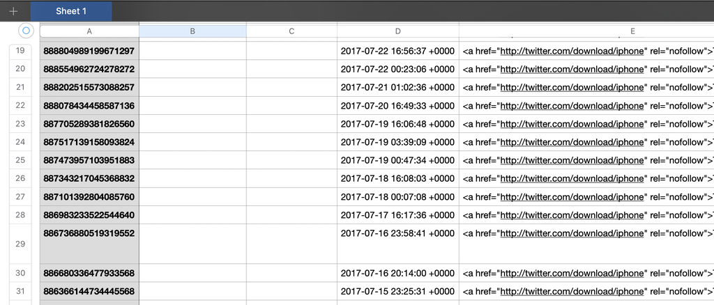

> This inspection gave a general idea of what the variables in this file are and which values they could and could not take. Many observations were empty (missing values).

> Programmatic inspection:

```python
# Display main characteristics of this table with info
twitter_archive.info()
```

```
<class 'pandas.core.frame.DataFrame'>
RangeIndex: 2356 entries, 0 to 2355
Data columns (total 17 columns):
 #   Column                      Non-Null Count  Dtype
---  ------                      --------------  -----
 0   tweet_id                    2356 non-null   int64
 1   in_reply_to_status_id       78 non-null     float64
 2   in_reply_to_user_id         78 non-null     float64
 3   timestamp                   2356 non-null   object
 4   source                      2356 non-null   object
 5   text                        2356 non-null   object
 6   retweeted_status_id         181 non-null    float64
 7   retweeted_status_user_id    181 non-null    float64
 8   retweeted_status_timestamp  181 non-null    object
 9   expanded_urls               2297 non-null   object
 10  rating_numerator            2356 non-null   int64
 11  rating_denominator          2356 non-null   int64
 12  name                        2356 non-null   object
 13  doggo                       2356 non-null   object
 14  floofer                     2356 non-null   object
 15  pupper                      2356 non-null   object
 16  puppo                       2356 non-null   object
dtypes: float64(4), int64(3), object(10)
memory usage: 313.0+ KB
```

```python
# Verify the data types of the timestamp
type(twitter_archive.timestamp[9])
```

```
str
```

```python
# Extract a sample of null values from retweeted_status_id
twitter_archive[twitter_archive['retweeted_status_id'].isnull()].sample(14)
```

|  | tweet_id | in_reply_to_status_id | in_reply_to_user_id | timestamp | source | text | retweeted_status_id | retweeted_status_user_id | retweeted_status_timestamp | expanded_urls | rating_numerator | rating_denominator | name | doggo | floofer | pupper | puppo |
| --- | --- | --- | --- | --- | --- | --- | --- | --- | --- | --- | --- | --- | --- | --- | --- | --- | --- |
| 1769 | 678380236862578688 | NaN | NaN | 2015-12-20 01:03:46 +0000 | <a href="http://twitter.com/download/iphone" r... | This is Crumpet. He underestimated the snow. Q... | NaN | NaN | NaN | https://twitter.com/dog_rates/status/678380236... | 10 | 10 | Crumpet | None | None | None | None |
| 1401 | 699434518667751424 | NaN | NaN | 2016-02-16 03:25:58 +0000 | <a href="http://twitter.com/download/iphone" r... | I know this is a tad late but here's a wonderf... | NaN | NaN | NaN | https://twitter.com/dog_rates/status/699434518... | 12 | 10 | None | None | None | pupper | None |
| 245 | 845812042753855489 | NaN | NaN | 2017-03-26 01:38:00 +0000 | <a href="http://twitter.com/download/iphone" r... | We usually don't rate polar bears but this one... | NaN | NaN | NaN | https://twitter.com/dog_rates/status/845812042... | 13 | 10 | None | None | None | None | None |
| 1929 | 674042553264685056 | NaN | NaN | 2015-12-08 01:47:22 +0000 | <a href="http://twitter.com/download/iphone" r... | Yea I can't handle the cuteness anymore. Curls... | NaN | NaN | NaN | https://twitter.com/dog_rates/status/674042553... | 12 | 10 | None | None | None | None | None |
| 1428 | 697616773278015490 | NaN | NaN | 2016-02-11 03:02:54 +0000 | <a href="http://twitter.com/download/iphone" r... | This pupper doubles as a hallway rug. Very rar... | NaN | NaN | NaN | https://twitter.com/dog_rates/status/697616773... | 11 | 10 | None | None | None | pupper | None |
| 1957 | 673583129559498752 | NaN | NaN | 2015-12-06 19:21:47 +0000 | <a href="http://twitter.com/download/iphone" r... | This is Sandy. She loves her spot by the tree.... | NaN | NaN | NaN | https://twitter.com/dog_rates/status/673583129... | 11 | 10 | Sandy | None | None | None | None |
| 1404 | 699370870310113280 | NaN | NaN | 2016-02-15 23:13:03 +0000 | <a href="http://twitter.com/download/iphone" r... | Say hello to Calbert. He doesn't have enough l... | NaN | NaN | NaN | https://twitter.com/dog_rates/status/699370870... | 11 | 10 | Calbert | None | None | None | None |
| 553 | 804026241225523202 | NaN | NaN | 2016-11-30 18:16:08 +0000 | <a href="http://twitter.com/download/iphone" r... | This is Bo. He's going to make me cry. 13/10 p... | NaN | NaN | NaN | https://twitter.com/dog_rates/status/804026241... | 13 | 10 | Bo | None | None | None | None |
| 1690 | 681339448655802368 | NaN | NaN | 2015-12-28 05:02:37 +0000 | <a href="http://twitter.com/download/iphone" r... | This is Asher. He's not wearing a seatbelt or ... | NaN | NaN | NaN | https://twitter.com/dog_rates/status/681339448... | 9 | 10 | Asher | None | None | None | None |
| 706 | 785533386513321988 | NaN | NaN | 2016-10-10 17:32:08 +0000 | <a href="http://twitter.com/download/iphone" r... | This is Dallas. Her tongue is ridiculous. 11/1... | NaN | NaN | NaN | https://twitter.com/dog_rates/status/785533386... | 11 | 10 | Dallas | None | None | None | None |
| 1468 | 694206574471057408 | NaN | NaN | 2016-02-01 17:11:59 +0000 | <a href="http://twitter.com/download/iphone" r... | "Martha come take a look at this. I'm so fed u... | NaN | NaN | NaN | https://twitter.com/dog_rates/status/694206574... | 10 | 10 | None | None | None | None | None |
| 2141 | 669993076832759809 | NaN | NaN | 2015-11-26 21:36:12 +0000 | <a href="http://twitter.com/download/iphone" r... | This is Zoey. Her dreams of becoming a hippo b... | NaN | NaN | NaN | https://twitter.com/dog_rates/status/669993076... | 9 | 10 | Zoey | None | None | None | None |
| 252 | 844973813909606400 | NaN | NaN | 2017-03-23 18:07:10 +0000 | <a href="http://twitter.com/download/iphone" r... | This is Brady. He's a recovering alcoholic. De... | NaN | NaN | NaN | https://twitter.com/dog_rates/status/844973813... | 12 | 10 | Brady | None | None | None | None |
| 1901 | 674646392044941312 | NaN | NaN | 2015-12-09 17:46:48 +0000 | <a href="http://twitter.com/download/iphone" r... | Two gorgeous dogs here. Little waddling dog is... | NaN | NaN | NaN | https://twitter.com/dog_rates/status/674646392... | 5 | 10 | None | None | None | None | None |

```python
# Look at the unique values
twitter_archive.nunique()
```

```
tweet_id                      2356
in_reply_to_status_id           77
in_reply_to_user_id             31
timestamp                     2356
source                           4
text                          2356
retweeted_status_id            181
retweeted_status_user_id        25
retweeted_status_timestamp     181
expanded_urls                 2218
rating_numerator                40
rating_denominator              18
name                           957
doggo                            2
floofer                          2
pupper                           2
puppo                            2
dtype: int64
```

```python
# Verify the most repeated value within the stages of dog 'doggo'
twitter_archive.doggo.mode()
```

```
0    None
dtype: object
```

```python
# Verify if all types of dog stages have 'None' as the most frequent value
twitter_archive.doggo.mode()[0] == twitter_archive.floofer.mode()[0] == twitter_archive.pupper.mode()[0] == twitter_archive.pupper.mode()
```

```
0    True
dtype: bool
```

```python
# Obtain number of entries that do not have a dog stage assigned
twitter_archive_subset = twitter_archive[(twitter_archive['doggo'] == 'None') & (twitter_archive['floofer'] == 'None') & (twitter_archive['pupper'] == 'None') & (twitter_archive['puppo'] == 'None')]
len(twitter_archive_subset)
```

```
1976
```

```python
# Verify if some rows have more than one dog stage assigned; first comparing all stages to doggos
duplicates = 0
stages =['floofer','pupper','puppo']
for col in stages:
        duplicates += len(twitter_archive.loc[(twitter_archive['doggo'] == 'doggo') & (twitter_archive[col] != 'None')])
print(duplicates)
```

```
14
```

```python
# Display descriptive statistics of the variables with describe
twitter_archive.describe()
```

|  | tweet_id | in_reply_to_status_id | in_reply_to_user_id | retweeted_status_id | retweeted_status_user_id | rating_numerator | rating_denominator |
| --- | --- | --- | --- | --- | --- | --- | --- |
| count | 2.356000e+03 | 7.800000e+01 | 7.800000e+01 | 1.810000e+02 | 1.810000e+02 | 2356.000000 | 2356.000000 |
| mean | 7.427716e+17 | 7.455079e+17 | 2.014171e+16 | 7.720400e+17 | 1.241698e+16 | 13.126486 | 10.455433 |
| std | 6.856705e+16 | 7.582492e+16 | 1.252797e+17 | 6.236928e+16 | 9.599254e+16 | 45.876648 | 6.745237 |
| min | 6.660209e+17 | 6.658147e+17 | 1.185634e+07 | 6.661041e+17 | 7.832140e+05 | 0.000000 | 0.000000 |
| 25% | 6.783989e+17 | 6.757419e+17 | 3.086374e+08 | 7.186315e+17 | 4.196984e+09 | 10.000000 | 10.000000 |
| 50% | 7.196279e+17 | 7.038708e+17 | 4.196984e+09 | 7.804657e+17 | 4.196984e+09 | 11.000000 | 10.000000 |
| 75% | 7.993373e+17 | 8.257804e+17 | 4.196984e+09 | 8.203146e+17 | 4.196984e+09 | 12.000000 | 10.000000 |
| max | 8.924206e+17 | 8.862664e+17 | 8.405479e+17 | 8.874740e+17 | 7.874618e+17 | 1776.000000 | 170.000000 |

```python
# Verify maximum values for numerator and denominator
twitter_archive[twitter_archive.rating_numerator == 1776.000000]
```

|  | tweet_id | in_reply_to_status_id | in_reply_to_user_id | timestamp | source | text | retweeted_status_id | retweeted_status_user_id | retweeted_status_timestamp | expanded_urls | rating_numerator | rating_denominator | name | doggo | floofer | pupper | puppo |
| --- | --- | --- | --- | --- | --- | --- | --- | --- | --- | --- | --- | --- | --- | --- | --- | --- | --- |
| 979 | 749981277374128128 | NaN | NaN | 2016-07-04 15:00:45 +0000 | <a href="https://about.twitter.com/products/tw... | This is Atticus. He's quite simply America af.... | NaN | NaN | NaN | https://twitter.com/dog_rates/status/749981277... | 1776 | 10 | Atticus | None | None | None | None |

```python
# Verify maximum values for numerator and denominator
twitter_archive[twitter_archive.rating_denominator == 170.000000]
```

|  | tweet_id | in_reply_to_status_id | in_reply_to_user_id | timestamp | source | text | retweeted_status_id | retweeted_status_user_id | retweeted_status_timestamp | expanded_urls | rating_numerator | rating_denominator | name | doggo | floofer | pupper | puppo |
| --- | --- | --- | --- | --- | --- | --- | --- | --- | --- | --- | --- | --- | --- | --- | --- | --- | --- |
| 1120 | 731156023742988288 | NaN | NaN | 2016-05-13 16:15:54 +0000 | <a href="http://twitter.com/download/iphone" r... | Say hello to this unbelievably well behaved sq... | NaN | NaN | NaN | https://twitter.com/dog_rates/status/731156023... | 204 | 170 | this | None | None | None | None |

```python
# Verify low values for the denominator
twitter_archive[twitter_archive.rating_denominator < 10]
```

|  | tweet_id | in_reply_to_status_id | in_reply_to_user_id | timestamp | source | text | retweeted_status_id | retweeted_status_user_id | retweeted_status_timestamp | expanded_urls | rating_numerator | rating_denominator | name | doggo | floofer | pupper | puppo |
| --- | --- | --- | --- | --- | --- | --- | --- | --- | --- | --- | --- | --- | --- | --- | --- | --- | --- |
| 313 | 835246439529840640 | 8.352460e+17 | 26259576.0 | 2017-02-24 21:54:03 +0000 | <a href="http://twitter.com/download/iphone" r... | @jonnysun @Lin_Manuel ok jomny I know you're e... | NaN | NaN | NaN | NaN | 960 | 0 | None | None | None | None | None |
| 516 | 810984652412424192 | NaN | NaN | 2016-12-19 23:06:23 +0000 | <a href="http://twitter.com/download/iphone" r... | Meet Sam. She smiles 24/7 &amp; secretly aspir... | NaN | NaN | NaN | https://www.gofundme.com/sams-smile,https://tw... | 24 | 7 | Sam | None | None | None | None |
| 2335 | 666287406224695296 | NaN | NaN | 2015-11-16 16:11:11 +0000 | <a href="http://twitter.com/download/iphone" r... | This is an Albanian 3 1/2 legged Episcopalian... | NaN | NaN | NaN | https://twitter.com/dog_rates/status/666287406... | 1 | 2 | an | None | None | None | None |

```python
# Verify low values for the numerator
len(twitter_archive[twitter_archive.rating_numerator < 10])
```

```
440
```

```python
# Search for duplicated tweets ID's with 'duplicated' method
twitter_archive[twitter_archive.tweet_id.duplicated()]
```

|  | tweet_id | in_reply_to_status_id | in_reply_to_user_id | timestamp | source | text | retweeted_status_id | retweeted_status_user_id | retweeted_status_timestamp | expanded_urls | rating_numerator | rating_denominator | name | doggo | floofer | pupper | puppo |
| --- | --- | --- | --- | --- | --- | --- | --- | --- | --- | --- | --- | --- | --- | --- | --- | --- | --- |

```python
# Search for duplicated texts with 'duplicated' method
twitter_archive[twitter_archive.text.duplicated()]
```

|  | tweet_id | in_reply_to_status_id | in_reply_to_user_id | timestamp | source | text | retweeted_status_id | retweeted_status_user_id | retweeted_status_timestamp | expanded_urls | rating_numerator | rating_denominator | name | doggo | floofer | pupper | puppo |
| --- | --- | --- | --- | --- | --- | --- | --- | --- | --- | --- | --- | --- | --- | --- | --- | --- | --- |

```python
# Inspect how many tweets are a response to other tweets
len(twitter_archive.in_reply_to_status_id.value_counts())
```

```
77
```

```python
# Inspect how many tweets are a response to other users
len(twitter_archive.in_reply_to_user_id.value_counts())
```

```
31
```

```python
# Random sample of the dataset
twitter_archive.sample(3)
```

|  | tweet_id | in_reply_to_status_id | in_reply_to_user_id | timestamp | source | text | retweeted_status_id | retweeted_status_user_id | retweeted_status_timestamp | expanded_urls | rating_numerator | rating_denominator | name | doggo | floofer | pupper | puppo |
| --- | --- | --- | --- | --- | --- | --- | --- | --- | --- | --- | --- | --- | --- | --- | --- | --- | --- |
| 579 | 800513324630806528 | NaN | NaN | 2016-11-21 01:37:04 +0000 | <a href="http://twitter.com/download/iphone" r... | This is Chef. Chef loves everyone and wants ev... | NaN | NaN | NaN | https://twitter.com/dog_rates/status/800513324... | 11 | 10 | Chef | None | None | None | None |
| 1749 | 679047485189439488 | NaN | NaN | 2015-12-21 21:15:11 +0000 | <a href="http://twitter.com/download/iphone" r... | This dog doesn't know how to stairs. Quite tra... | NaN | NaN | NaN | https://twitter.com/dog_rates/status/679047485... | 9 | 10 | None | None | None | None | None |
| 358 | 830097400375152640 | NaN | NaN | 2017-02-10 16:53:37 +0000 | <a href="http://twitter.com/download/iphone" r... | Meet Samson. He's absolute fluffy perfection. ... | NaN | NaN | NaN | https://www.gofundme.com/sick-baby-samson,http... | 13 | 10 | Samson | None | None | None | None |

1. `image_predictions` table

   > First a visual inspection was carried out with the software 'Numbers'.

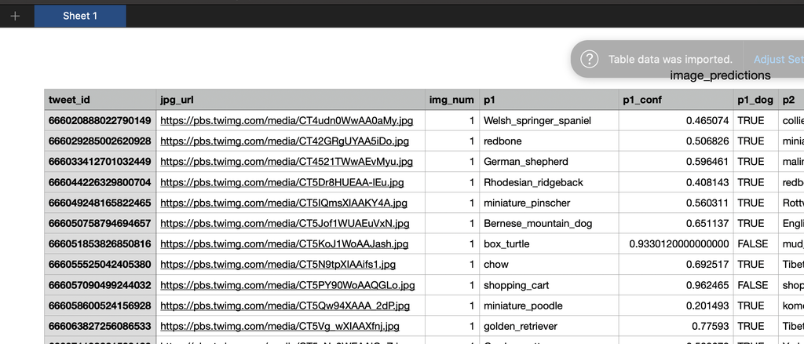

> As with the previous table, since these values are so diverse and are not ruled by many constrains the visual search did not deliver especially useful insights.

```python
# Display main characteristics of this table with info
image_predictions.info()
```

```
<class 'pandas.core.frame.DataFrame'>
RangeIndex: 2075 entries, 0 to 2074
Data columns (total 12 columns):
 #   Column    Non-Null Count  Dtype
---  ------    --------------  -----
 0   tweet_id  2075 non-null   int64
 1   jpg_url   2075 non-null   object
 2   img_num   2075 non-null   int64
 3   p1        2075 non-null   object
 4   p1_conf   2075 non-null   float64
 5   p1_dog    2075 non-null   bool
 6   p2        2075 non-null   object
 7   p2_conf   2075 non-null   float64
 8   p2_dog    2075 non-null   bool
 9   p3        2075 non-null   object
 10  p3_conf   2075 non-null   float64
 11  p3_dog    2075 non-null   bool
dtypes: bool(3), float64(3), int64(2), object(4)
memory usage: 152.1+ KB
```

```python
# Verify the data types of the predictions
type(image_predictions.p1[9])
```

```
str
```

```python
# Look at unique values
image_predictions.nunique()
```

```
tweet_id    2075
jpg_url     2009
img_num        4
p1           378
p1_conf     2006
p1_dog         2
p2           405
p2_conf     2004
p2_dog         2
p3           408
p3_conf     2006
p3_dog         2
dtype: int64
```

```python
# Check most predicted breeds by algorithm attempts
image_predictions.p1.mode()
```

```
0    golden_retriever
dtype: object
```

```python
# Check most predicted breeds by algorithm attempts
image_predictions.p2.mode()
```

```
0    Labrador_retriever
dtype: object
```

```python
# Check most predicted breeds by algorithm attempts
image_predictions.p3.mode()
```

```
0    Labrador_retriever
dtype: object
```

```python
# Display descriptive statistics of the variables with describe
image_predictions.describe()
```

|  | tweet_id | img_num | p1_conf | p2_conf | p3_conf |
| --- | --- | --- | --- | --- | --- |
| count | 2.075000e+03 | 2075.000000 | 2075.000000 | 2.075000e+03 | 2.075000e+03 |
| mean | 7.384514e+17 | 1.203855 | 0.594548 | 1.345886e-01 | 6.032417e-02 |
| std | 6.785203e+16 | 0.561875 | 0.271174 | 1.006657e-01 | 5.090593e-02 |
| min | 6.660209e+17 | 1.000000 | 0.044333 | 1.011300e-08 | 1.740170e-10 |
| 25% | 6.764835e+17 | 1.000000 | 0.364412 | 5.388625e-02 | 1.622240e-02 |
| 50% | 7.119988e+17 | 1.000000 | 0.588230 | 1.181810e-01 | 4.944380e-02 |
| 75% | 7.932034e+17 | 1.000000 | 0.843855 | 1.955655e-01 | 9.180755e-02 |
| max | 8.924206e+17 | 4.000000 | 1.000000 | 4.880140e-01 | 2.734190e-01 |

```python
# Inspect value with confidence equal to 1
image_predictions[image_predictions.p1_conf == 1]
```

|  | tweet_id | jpg_url | img_num | p1 | p1_conf | p1_dog | p2 | p2_conf | p2_dog | p3 | p3_conf | p3_dog |
| --- | --- | --- | --- | --- | --- | --- | --- | --- | --- | --- | --- | --- |
| 106 | 667866724293877760 | https://pbs.twimg.com/media/CUS9PlUWwAANeAD.jpg | 1 | jigsaw_puzzle | 1.0 | False | prayer_rug | 1.011300e-08 | False | doormat | 1.740170e-10 | False |

```python
# Check how many entries have incorrect predictions for all attempts
image_predictions_subset = image_predictions[(image_predictions['p1_dog'] == False) & (image_predictions['p2_dog'] == False) & (image_predictions['p3_dog'] == False) ]
len(image_predictions_subset)
```

```
324
```

```python
# Search for duplicated tweets with 'duplicated' method
image_predictions[image_predictions.tweet_id.duplicated()]
```

|  | tweet_id | jpg_url | img_num | p1 | p1_conf | p1_dog | p2 | p2_conf | p2_dog | p3 | p3_conf | p3_dog |
| --- | --- | --- | --- | --- | --- | --- | --- | --- | --- | --- | --- | --- |

```python
# Show a random sample of the dataset
image_predictions.sample(4)
```

|  | tweet_id | jpg_url | img_num | p1 | p1_conf | p1_dog | p2 | p2_conf | p2_dog | p3 | p3_conf | p3_dog |
| --- | --- | --- | --- | --- | --- | --- | --- | --- | --- | --- | --- | --- |
| 947 | 704761120771465216 | https://pbs.twimg.com/media/CcfQgHVWoAAxauy.jpg | 1 | Siamese_cat | 0.202294 | False | Chihuahua | 0.100418 | True | basenji | 0.072097 | True |
| 1075 | 717047459982213120 | https://pbs.twimg.com/media/CfN23ArXEAEkZkz.jpg | 1 | golden_retriever | 0.983548 | True | Labrador_retriever | 0.012185 | True | cocker_spaniel | 0.002412 | True |
| 1780 | 828650029636317184 | https://pbs.twimg.com/media/C3_0yhCWEAETXj2.jpg | 1 | golden_retriever | 0.649209 | True | Chesapeake_Bay_retriever | 0.198560 | True | vizsla | 0.056200 | True |
| 342 | 672256522047614977 | https://pbs.twimg.com/media/CVRVvRMWEAIBKOP.jpg | 1 | ostrich | 0.999004 | False | Arabian_camel | 0.000512 | False | llama | 0.000147 | False |

1. `detailed_tweets` table

   > The visual inspection was carried out using Pandas.

```python
detailed_tweets
```

|  | created_at | id | id_str | full_text | truncated | display_text_range | entities | extended_entities | source | in_reply_to_status_id | ... | favorited | retweeted | possibly_sensitive | possibly_sensitive_appealable | lang | retweeted_status | quoted_status_id | quoted_status_id_str | quoted_status_permalink | quoted_status |
| --- | --- | --- | --- | --- | --- | --- | --- | --- | --- | --- | --- | --- | --- | --- | --- | --- | --- | --- | --- | --- | --- |
| 0 | Tue Aug 01 16:23:56 +0000 2017 | 892420643555336193 | 892420643555336193 | This is Phineas. He's a mystical boy. Only eve... | False | [0, 85] | {'hashtags': [], 'symbols': [], 'user_mentions... | {'media': [{'id': 892420639486877696, 'id_str'... | <a href="http://twitter.com/download/iphone" r... | NaN | ... | False | False | False | False | en | NaN | NaN | NaN | NaN | NaN |
| 1 | Tue Aug 01 00:17:27 +0000 2017 | 892177421306343426 | 892177421306343426 | This is Tilly. She's just checking pup on you.... | False | [0, 138] | {'hashtags': [], 'symbols': [], 'user_mentions... | {'media': [{'id': 892177413194625024, 'id_str'... | <a href="http://twitter.com/download/iphone" r... | NaN | ... | False | False | False | False | en | NaN | NaN | NaN | NaN | NaN |
| 2 | Mon Jul 31 00:18:03 +0000 2017 | 891815181378084864 | 891815181378084864 | This is Archie. He is a rare Norwegian Pouncin... | False | [0, 121] | {'hashtags': [], 'symbols': [], 'user_mentions... | {'media': [{'id': 891815175371796480, 'id_str'... | <a href="http://twitter.com/download/iphone" r... | NaN | ... | False | False | False | False | en | NaN | NaN | NaN | NaN | NaN |
| 3 | Sun Jul 30 15:58:51 +0000 2017 | 891689557279858688 | 891689557279858688 | This is Darla. She commenced a snooze mid meal... | False | [0, 79] | {'hashtags': [], 'symbols': [], 'user_mentions... | {'media': [{'id': 891689552724799489, 'id_str'... | <a href="http://twitter.com/download/iphone" r... | NaN | ... | False | False | False | False | en | NaN | NaN | NaN | NaN | NaN |
| 4 | Sat Jul 29 16:00:24 +0000 2017 | 891327558926688256 | 891327558926688256 | This is Franklin. He would like you to stop ca... | False | [0, 138] | {'hashtags': [{'text': 'BarkWeek', 'indices': ... | {'media': [{'id': 891327551943041024, 'id_str'... | <a href="http://twitter.com/download/iphone" r... | NaN | ... | False | False | False | False | en | NaN | NaN | NaN | NaN | NaN |
| ... | ... | ... | ... | ... | ... | ... | ... | ... | ... | ... | ... | ... | ... | ... | ... | ... | ... | ... | ... | ... | ... |
| 2326 | Mon Nov 16 00:24:50 +0000 2015 | 666049248165822465 | 666049248165822465 | Here we have a 1949 1st generation vulpix. Enj... | False | [0, 120] | {'hashtags': [], 'symbols': [], 'user_mentions... | {'media': [{'id': 666049244999131136, 'id_str'... | <a href="http://twitter.com/download/iphone" r... | NaN | ... | False | False | False | False | en | NaN | NaN | NaN | NaN | NaN |
| 2327 | Mon Nov 16 00:04:52 +0000 2015 | 666044226329800704 | 666044226329800704 | This is a purebred Piers Morgan. Loves to Netf... | False | [0, 137] | {'hashtags': [], 'symbols': [], 'user_mentions... | {'media': [{'id': 666044217047650304, 'id_str'... | <a href="http://twitter.com/download/iphone" r... | NaN | ... | False | False | False | False | en | NaN | NaN | NaN | NaN | NaN |
| 2328 | Sun Nov 15 23:21:54 +0000 2015 | 666033412701032449 | 666033412701032449 | Here is a very happy pup. Big fan of well-main... | False | [0, 130] | {'hashtags': [], 'symbols': [], 'user_mentions... | {'media': [{'id': 666033409081393153, 'id_str'... | <a href="http://twitter.com/download/iphone" r... | NaN | ... | False | False | False | False | en | NaN | NaN | NaN | NaN | NaN |
| 2329 | Sun Nov 15 23:05:30 +0000 2015 | 666029285002620928 | 666029285002620928 | This is a western brown Mitsubishi terrier. Up... | False | [0, 139] | {'hashtags': [], 'symbols': [], 'user_mentions... | {'media': [{'id': 666029276303482880, 'id_str'... | <a href="http://twitter.com/download/iphone" r... | NaN | ... | False | False | False | False | en | NaN | NaN | NaN | NaN | NaN |
| 2330 | Sun Nov 15 22:32:08 +0000 2015 | 666020888022790149 | 666020888022790149 | Here we have a Japanese Irish Setter. Lost eye... | False | [0, 131] | {'hashtags': [], 'symbols': [], 'user_mentions... | {'media': [{'id': 666020881337073664, 'id_str'... | <a href="http://twitter.com/download/iphone" r... | NaN | ... | False | False | False | False | en | NaN | NaN | NaN | NaN | NaN |

2331 rows × 32 columns

> This table has a lot of information but many of the entries are empty (missing values).

```python
# Display main characteristics of this table with info
detailed_tweets.info()
```

```
<class 'pandas.core.frame.DataFrame'>
RangeIndex: 2331 entries, 0 to 2330
Data columns (total 32 columns):
 #   Column                         Non-Null Count  Dtype
---  ------                         --------------  -----
 0   created_at                     2331 non-null   object
 1   id                             2331 non-null   int64
 2   id_str                         2331 non-null   object
 3   full_text                      2331 non-null   object
 4   truncated                      2331 non-null   bool
 5   display_text_range             2331 non-null   object
 6   entities                       2331 non-null   object
 7   extended_entities              2059 non-null   object
 8   source                         2331 non-null   object
 9   in_reply_to_status_id          77 non-null     float64
```

[output cut: 24 more lines]

```python
# Verify the data types of the column 'created at'
type(detailed_tweets.created_at[9])
```

```
str
```

```python
# verify the data types of the column 'possibly_sensitive'
type(detailed_tweets.possibly_sensitive[9])
```

```
bool
```

```python
# Display descriptive statistics
detailed_tweets.describe()
```

|  | id | in_reply_to_status_id | in_reply_to_user_id | retweet_count | favorite_count | quoted_status_id |
| --- | --- | --- | --- | --- | --- | --- |
| count | 2.331000e+03 | 7.700000e+01 | 7.700000e+01 | 2331.000000 | 2331.000000 | 2.600000e+01 |
| mean | 7.419079e+17 | 7.440692e+17 | 2.040329e+16 | 2656.050622 | 7464.755899 | 8.113972e+17 |
| std | 6.823170e+16 | 7.524295e+16 | 1.260797e+17 | 4492.226874 | 11590.528926 | 6.295843e+16 |
| min | 6.660209e+17 | 6.658147e+17 | 1.185634e+07 | 1.000000 | 0.000000 | 6.721083e+17 |
| 25% | 6.782670e+17 | 6.757073e+17 | 3.589728e+08 | 539.000000 | 1299.000000 | 7.761338e+17 |
| 50% | 7.182469e+17 | 7.032559e+17 | 4.196984e+09 | 1243.000000 | 3244.000000 | 8.281173e+17 |
| 75% | 7.986692e+17 | 8.233264e+17 | 4.196984e+09 | 3083.500000 | 9142.500000 | 8.637581e+17 |
| max | 8.924206e+17 | 8.862664e+17 | 8.405479e+17 | 76336.000000 | 154049.000000 | 8.860534e+17 |

```python
# Search for duplicated tweets with 'duplicated'
detailed_tweets[detailed_tweets.id.duplicated()]
```

|  | created_at | id | id_str | full_text | truncated | display_text_range | entities | extended_entities | source | in_reply_to_status_id | ... | favorited | retweeted | possibly_sensitive | possibly_sensitive_appealable | lang | retweeted_status | quoted_status_id | quoted_status_id_str | quoted_status_permalink | quoted_status |
| --- | --- | --- | --- | --- | --- | --- | --- | --- | --- | --- | --- | --- | --- | --- | --- | --- | --- | --- | --- | --- | --- |

0 rows × 32 columns

```python
# Show a random sample of the dataset
detailed_tweets.sample(4)
```

|  | created_at | id | id_str | full_text | truncated | display_text_range | entities | extended_entities | source | in_reply_to_status_id | ... | favorited | retweeted | possibly_sensitive | possibly_sensitive_appealable | lang | retweeted_status | quoted_status_id | quoted_status_id_str | quoted_status_permalink | quoted_status |
| --- | --- | --- | --- | --- | --- | --- | --- | --- | --- | --- | --- | --- | --- | --- | --- | --- | --- | --- | --- | --- | --- |
| 1219 | Mon Mar 21 17:30:03 +0000 2016 | 711968124745228288 | 711968124745228288 | Meet Winston. He's trapped in a cup of coffee.... | False | [0, 106] | {'hashtags': [], 'symbols': [], 'user_mentions... | {'media': [{'id': 711968119305211904, 'id_str'... | <a href="http://twitter.com/download/iphone" r... | NaN | ... | False | False | False | False | en | NaN | NaN | NaN | NaN | NaN |
| 1816 | Sun Dec 13 03:21:34 +0000 2015 | 675878199931371520 | 675878199931371520 | Ok, I'll admit this is a pretty adorable bunny... | False | [0, 134] | {'hashtags': [], 'symbols': [], 'user_mentions... | {'media': [{'id': 675878195854483457, 'id_str'... | <a href="http://twitter.com/download/iphone" r... | NaN | ... | False | False | False | False | en | NaN | NaN | NaN | NaN | NaN |
| 2244 | Fri Nov 20 01:06:48 +0000 2015 | 667509364010450944 | 667509364010450944 | This a Norwegian Pewterschmidt named Tickles. ... | False | [0, 116] | {'hashtags': [], 'symbols': [], 'user_mentions... | {'media': [{'id': 667509363477577728, 'id_str'... | <a href="http://twitter.com" rel="nofollow">Tw... | NaN | ... | False | False | False | False | en | NaN | NaN | NaN | NaN | NaN |
| 2156 | Tue Nov 24 03:29:51 +0000 2015 | 668994913074286592 | 668994913074286592 | Two gorgeous pups here. Both have cute fake ho... | False | [0, 140] | {'hashtags': [], 'symbols': [], 'user_mentions... | {'media': [{'id': 668994907227430913, 'id_str'... | <a href="http://twitter.com/download/iphone" r... | NaN | ... | False | False | False | False | en | NaN | NaN | NaN | NaN | NaN |

4 rows × 32 columns

> The last assessment is a verification of duplicated columns among the three tables

```python
# Join all columns in a list and verify duplicated ones
all_columns = pd.Series(list(twitter_archive) + list(image_predictions) + list(detailed_tweets))
all_columns[all_columns.duplicated()]
```

```
17                 tweet_id
37                   source
38    in_reply_to_status_id
40      in_reply_to_user_id
dtype: object
```

#### Observations:

The main observations regarding data quality and tidiness are summarized below. Quality issues are divided by table and tidiness issues are presented together for all tables.

##### Quality

###### `tweet_archive` table

- Data type of timestamp is str.
- Missing values from 6 out of 17 columns.
- Maximum rating numerators and denominators could be outliers moreover some denominator values are lower than 10.
- Predictions of dog "stages" are mostly empty.
- Some predictions of dog "stages" are duplicated.
- Some columns are not required for the analysis.

###### `image_predictions` table

- Column names could be more descriptive.

###### `detailed_tweets` table

- Column names could be more descriptive.
- Missing values from 17 out of 32 columns.
- Some columns are totally empty, and imputing is not feasible.
- Data type of timeStamp is str.
- Some columns are not required for the analysis

##### Tidiness

- The dog stage present in the `twitter_archive` table should be one column instead of four.
- The `twitter_archive` table and `detailed_tweet` share duplicated information. By dropping these duplicates they could constitute more coherent observational units. For the sake of this analysis the columns favorite count and retweet count will be taken as response variables and will be analyzed based on: Tweet information (from the `detailed_tweet` table) and their relationship with the dogs stage data from the `twitter_archive` table. With this in mind:
  - duplicated columns will be dropped from the `twitter_archive` table
  - The 'response' columns from `detailed_tweet` will be merged to the `twitter_archive` table.

### Cleaning

The cleaning efforts carried out so as to fix the issues discovered in the previous section, are described herein.

```python
# Copy the datasets before modifying them separately in case cleaning operations are not correct
twitter_archive_clean = twitter_archive.copy()
```

```python
image_predictions_clean = image_predictions.copy()
```

```python
detailed_tweets_clean = detailed_tweets.copy()
```

#### 1. Missing Data

##### 1.1 `twitter_archive`: Missing values (Not necessary ones)

##### Define

Drop the columns with missing values that are not necessary for the analysis using drop() method.

##### Code

```python
# Drop columns that will not be included in the analysis using drop() method
# Copy the datasets before modifying them
twitter_archive_clean.drop(twitter_archive_clean.columns[[1,2,6,7,8,9]], axis = 1, inplace = True)
```

##### Test

```python
# Verify that columns have been drop with info()
twitter_archive_clean.info()
```

```
<class 'pandas.core.frame.DataFrame'>
RangeIndex: 2356 entries, 0 to 2355
Data columns (total 11 columns):
 #   Column              Non-Null Count  Dtype
---  ------              --------------  -----
 0   tweet_id            2356 non-null   int64
 1   timestamp           2356 non-null   object
 2   source              2356 non-null   object
 3   text                2356 non-null   object
 4   rating_numerator    2356 non-null   int64
 5   rating_denominator  2356 non-null   int64
 6   name                2356 non-null   object
 7   doggo               2356 non-null   object
 8   floofer             2356 non-null   object
 9   pupper              2356 non-null   object
 10  puppo               2356 non-null   object
dtypes: int64(3), object(8)
memory usage: 202.6+ KB
```

##### 1.2 `twitter_archive`: Missing values (imputable ones)

##### Define

Re- extract the stages of dogs matching their definitions and popular synonyms to the captions included in each tweet's text. This will be done in the tidiness section.

##### 1.3 `detailed_tweets`: Missing values

##### Define

Drop the columns with missing values that are not necessary for the analysis, the ones that have little or no values (and imputation is not possible) using drop() method.

##### Code

```python
# Verify the index of the columns
detailed_tweets_clean.info()
```

```
<class 'pandas.core.frame.DataFrame'>
RangeIndex: 2331 entries, 0 to 2330
Data columns (total 32 columns):
 #   Column                         Non-Null Count  Dtype
---  ------                         --------------  -----
 0   created_at                     2331 non-null   object
 1   id                             2331 non-null   int64
 2   id_str                         2331 non-null   object
 3   full_text                      2331 non-null   object
 4   truncated                      2331 non-null   bool
 5   display_text_range             2331 non-null   object
 6   entities                       2331 non-null   object
 7   extended_entities              2059 non-null   object
 8   source                         2331 non-null   object
 9   in_reply_to_status_id          77 non-null     float64
```

[output cut: 24 more lines]

```python
# Drop columns previously targeted using drop() method
detailed_tweets_clean.drop(detailed_tweets_clean.columns[[2,7,10,11,12,13,15,16,17,18,22,23,25,28,29,30,31]], axis = 1, inplace = True)
```

##### Test

```python
# Verify that columns have been drop with info()
detailed_tweets_clean.info()
```

```
<class 'pandas.core.frame.DataFrame'>
RangeIndex: 2331 entries, 0 to 2330
Data columns (total 15 columns):
 #   Column                 Non-Null Count  Dtype
---  ------                 --------------  -----
 0   created_at             2331 non-null   object
 1   id                     2331 non-null   int64
 2   full_text              2331 non-null   object
 3   truncated              2331 non-null   bool
 4   display_text_range     2331 non-null   object
 5   entities               2331 non-null   object
 6   source                 2331 non-null   object
 7   in_reply_to_status_id  77 non-null     float64
 8   user                   2331 non-null   object
 9   is_quote_status        2331 non-null   bool
 10  retweet_count          2331 non-null   int64
 11  favorite_count         2331 non-null   int64
 12  possibly_sensitive     2196 non-null   object
 13  lang                   2331 non-null   object
 14  retweeted_status       163 non-null    object
dtypes: bool(2), float64(1), int64(3), object(9)
memory usage: 241.4+ KB
```

#### 2. Tidiness

##### 2.1 The type of dog in the `twitter_archive` table should be one column instead of four.

##### Define

The process to improve the tidiness of the data frame, drop duplicates and fix the missing/redundant values (by imputing new ones) will be the following:

1. Melt columns describing dogs’ stages;
2. Drop redundant values produced by ‘Melt’;
3. Extract those rows that already had 'stage' values and drop the 14 entries with double value;
4. Apply a customized function to obtain new stages from the text column;
5. Concatenate both data frames, one with stages obtained from the function developed and the ones that had values already.

##### code

```python
# Melt redundant columns (doggo, pupper...)
twitter_archive_clean = pd.melt(twitter_archive_clean, id_vars=['tweet_id','timestamp', 'source', 'text', 'rating_numerator', 'rating_denominator', 'name'], value_vars=['doggo', 'floofer', 'pupper', 'puppo'], var_name='stage')
```

```python
# Drop the duplicates values except for those rows with stage information and their duplicates
twitter_archive_clean = twitter_archive_clean.drop_duplicates(subset = ['tweet_id','value'])
```

```python
# Save those columns with info and store them away and drop the 14 identified duplicated
stages_temp = twitter_archive_clean[twitter_archive_clean['stage'] == twitter_archive_clean['value']]
# Duplicates in this column are to be dropped randomly because both have the same chances to be right
stages_temp = stages_temp.drop_duplicates(subset=['tweet_id'], keep='last')
```

```python
# Drop all rows with tweet_id duplicates
twitter_archive_clean = twitter_archive_clean.drop_duplicates(subset=['tweet_id'], keep=False)
```

```python
# Create a function that compares common adjectives to those of the dogs definition
def DogClassifificator(word):
    #Create a list with popular and descriptive dog's adjectives
    adjectives = ['pupper', 'puppy','pup','little', 'young', 'old boy', 'floof', 'old boy', 'boy', 'mature', 'dogo']
    #Create specific lists for different stages (Also could be indexing of adjectives)
    puppy = ['pupper', 'puppy', 'pup', 'little']
    pupper = ['young', 'old boy']
    floofer = ['floof', 'fur']
    doggo = ['old boy', 'boy', 'mature', 'dogo']
    #Loop the tweet’s texts in search of matches with the aforementioned adjectives
    for adjective in adjectives:
        if (adjective in word and adjective in puppy):
            value =  'puppo'
            break
        elif (adjective in word and adjective in pupper):
            value =  'pupper'
            break
        elif (adjective in word and adjective in floofer):
            value = 'floofer'
            break
        elif (adjective in word and adjective in doggo):
            value =  'doggo'
            break
        else:
            value = 'None'
    return value

# Apply the function and create a variable called Stage_dog
twitter_archive_clean["value"]= twitter_archive_clean["text"].apply(DogClassifificator)
```

```python
# Concatenate classified and stored dataframes to have back the 2356 total
twitter_archive_clean = pd.concat([twitter_archive_clean, stages_temp])
```

```python
# Drop stage column
twitter_archive_clean = twitter_archive_clean.drop(['stage'], axis=1)
```

```python
# Rename value column
twitter_archive_clean.rename(columns={'value':'dog_stage'}, inplace=True)
```

##### Test

```python
# Inspect the dataset
twitter_archive_clean.head()
```

|  | tweet_id | timestamp | source | text | rating_numerator | rating_denominator | name | dog_stage |
| --- | --- | --- | --- | --- | --- | --- | --- | --- |
| 0 | 892420643555336193 | 2017-08-01 16:23:56 +0000 | <a href="http://twitter.com/download/iphone" r... | This is Phineas. He's a mystical boy. Only eve... | 13 | 10 | Phineas | doggo |
| 1 | 892177421306343426 | 2017-08-01 00:17:27 +0000 | <a href="http://twitter.com/download/iphone" r... | This is Tilly. She's just checking pup on you.... | 13 | 10 | Tilly | puppo |
| 2 | 891815181378084864 | 2017-07-31 00:18:03 +0000 | <a href="http://twitter.com/download/iphone" r... | This is Archie. He is a rare Norwegian Pouncin... | 12 | 10 | Archie | None |
| 3 | 891689557279858688 | 2017-07-30 15:58:51 +0000 | <a href="http://twitter.com/download/iphone" r... | This is Darla. She commenced a snooze mid meal... | 13 | 10 | Darla | None |
| 4 | 891327558926688256 | 2017-07-29 16:00:24 +0000 | <a href="http://twitter.com/download/iphone" r... | This is Franklin. He would like you to stop ca... | 12 | 10 | Franklin | None |

```python
# Inspect the dataset
twitter_archive_clean.info()
```

```
<class 'pandas.core.frame.DataFrame'>
Int64Index: 2356 entries, 0 to 8151
Data columns (total 8 columns):
 #   Column              Non-Null Count  Dtype
---  ------              --------------  -----
 0   tweet_id            2356 non-null   int64
 1   timestamp           2356 non-null   object
 2   source              2356 non-null   object
 3   text                2356 non-null   object
 4   rating_numerator    2356 non-null   int64
 5   rating_denominator  2356 non-null   int64
 6   name                2356 non-null   object
 7   dog_stage           2356 non-null   object
dtypes: int64(3), object(5)
memory usage: 165.7+ KB
```

##### 2.1 Consistency between `twitter_archive` table and `detailed_tweet` as separate observational units

##### 2.2.1 The `twitter_archive` table and `detailed_tweet` have duplicated entries

##### Define

Drop duplicated/redundant columns between `twitter_archive` and `detailed_tweet` table.

##### Code

```python
# Drop redundant columns
twitter_archive_clean.drop(twitter_archive_clean.columns[[1,2,3]], axis = 1, inplace = True)
```

##### Test

```python
# Verify that columns have been dropped with info()
twitter_archive_clean.info()
```

```
<class 'pandas.core.frame.DataFrame'>
Int64Index: 2356 entries, 0 to 8151
Data columns (total 5 columns):
 #   Column              Non-Null Count  Dtype
---  ------              --------------  -----
 0   tweet_id            2356 non-null   int64
 1   rating_numerator    2356 non-null   int64
 2   rating_denominator  2356 non-null   int64
 3   name                2356 non-null   object
 4   dog_stage           2356 non-null   object
dtypes: int64(3), object(2)
memory usage: 110.4+ KB
```

```python
# Verify columns and shape with info()
detailed_tweets_clean.info()
```

```
<class 'pandas.core.frame.DataFrame'>
RangeIndex: 2331 entries, 0 to 2330
Data columns (total 15 columns):
 #   Column                 Non-Null Count  Dtype
---  ------                 --------------  -----
 0   created_at             2331 non-null   object
 1   id                     2331 non-null   int64
 2   full_text              2331 non-null   object
 3   truncated              2331 non-null   bool
 4   display_text_range     2331 non-null   object
 5   entities               2331 non-null   object
 6   source                 2331 non-null   object
 7   in_reply_to_status_id  77 non-null     float64
 8   user                   2331 non-null   object
 9   is_quote_status        2331 non-null   bool
 10  retweet_count          2331 non-null   int64
 11  favorite_count         2331 non-null   int64
 12  possibly_sensitive     2196 non-null   object
 13  lang                   2331 non-null   object
 14  retweeted_status       163 non-null    object
dtypes: bool(2), float64(1), int64(3), object(9)
memory usage: 241.4+ KB
```

##### 2.2.2 The 'response' columns favorited and retweeted will be merged from `detailed_tweet` to `twitter_archive`

##### Define

Merge the *favorite_count* and *retweet_count* columns to the `twitter_archive` table, joining on *tweet_id*.

##### Code

```python
# Rename id column to match that of twitter_archive
detailed_tweets_clean.rename(columns={'id':'tweet_id'}, inplace=True)
```

```python
# Compare identifiers of both columns
twitter_archive_clean['tweet_id'].isin(detailed_tweets_clean['tweet_id']).value_counts()
```

```
True     2331
False      25
Name: tweet_id, dtype: int64
```

```python
# Merge response variables to table 1 as another table (to carry out the exploratory analysis)
twitter_archive_clean2 = pd.merge(twitter_archive_clean, detailed_tweets_clean, on=['tweet_id'], how='inner')
twitter_archive_clean2.head()
```

|  | tweet_id | rating_numerator | rating_denominator | name | dog_stage | created_at | full_text | truncated | display_text_range | entities | source | in_reply_to_status_id | user | is_quote_status | retweet_count | favorite_count | possibly_sensitive | lang | retweeted_status |
| --- | --- | --- | --- | --- | --- | --- | --- | --- | --- | --- | --- | --- | --- | --- | --- | --- | --- | --- | --- |
| 0 | 892420643555336193 | 13 | 10 | Phineas | doggo | Tue Aug 01 16:23:56 +0000 2017 | This is Phineas. He's a mystical boy. Only eve... | False | [0, 85] | {'hashtags': [], 'symbols': [], 'user_mentions... | <a href="http://twitter.com/download/iphone" r... | NaN | {'id': 4196983835, 'id_str': '4196983835', 'na... | False | 7554 | 35731 | False | en | NaN |
| 1 | 892177421306343426 | 13 | 10 | Tilly | puppo | Tue Aug 01 00:17:27 +0000 2017 | This is Tilly. She's just checking pup on you.... | False | [0, 138] | {'hashtags': [], 'symbols': [], 'user_mentions... | <a href="http://twitter.com/download/iphone" r... | NaN | {'id': 4196983835, 'id_str': '4196983835', 'na... | False | 5599 | 30872 | False | en | NaN |
| 2 | 891815181378084864 | 12 | 10 | Archie | None | Mon Jul 31 00:18:03 +0000 2017 | This is Archie. He is a rare Norwegian Pouncin... | False | [0, 121] | {'hashtags': [], 'symbols': [], 'user_mentions... | <a href="http://twitter.com/download/iphone" r... | NaN | {'id': 4196983835, 'id_str': '4196983835', 'na... | False | 3709 | 23224 | False | en | NaN |
| 3 | 891689557279858688 | 13 | 10 | Darla | None | Sun Jul 30 15:58:51 +0000 2017 | This is Darla. She commenced a snooze mid meal... | False | [0, 79] | {'hashtags': [], 'symbols': [], 'user_mentions... | <a href="http://twitter.com/download/iphone" r... | NaN | {'id': 4196983835, 'id_str': '4196983835', 'na... | False | 7739 | 39020 | False | en | NaN |
| 4 | 891327558926688256 | 12 | 10 | Franklin | None | Sat Jul 29 16:00:24 +0000 2017 | This is Franklin. He would like you to stop ca... | False | [0, 138] | {'hashtags': [{'text': 'BarkWeek', 'indices': ... | <a href="http://twitter.com/download/iphone" r... | NaN | {'id': 4196983835, 'id_str': '4196983835', 'na... | False | 8335 | 37280 | False | en | NaN |

##### Test

```python
#Verify columns and shape with info()
twitter_archive_clean2.info()
```

```
<class 'pandas.core.frame.DataFrame'>
Int64Index: 2331 entries, 0 to 2330
Data columns (total 19 columns):
 #   Column                 Non-Null Count  Dtype
---  ------                 --------------  -----
 0   tweet_id               2331 non-null   int64
 1   rating_numerator       2331 non-null   int64
 2   rating_denominator     2331 non-null   int64
 3   name                   2331 non-null   object
 4   dog_stage              2331 non-null   object
 5   created_at             2331 non-null   object
 6   full_text              2331 non-null   object
 7   truncated              2331 non-null   bool
 8   display_text_range     2331 non-null   object
 9   entities               2331 non-null   object
 10  source                 2331 non-null   object
 11  in_reply_to_status_id  77 non-null     float64
 12  user                   2331 non-null   object
 13  is_quote_status        2331 non-null   bool
 14  retweet_count          2331 non-null   int64
 15  favorite_count         2331 non-null   int64
 16  possibly_sensitive     2196 non-null   object
 17  lang                   2331 non-null   object
 18  retweeted_status       163 non-null    object
dtypes: bool(2), float64(1), int64(5), object(11)
memory usage: 332.3+ KB
```

#### 3. Quality

Some of the quality issues have been tackled during the tidiness and missing data operations.

`twitter_archive` table:

##### 3.1 Invalid data among numerators and denominator ratings

##### Define

Inspect and handle numerators and denominators which could be outliers.

##### Code

```python
#inspect the outliers and drop the ones that could be errors:
twitter_archive_clean2.rating_numerator.value_counts()

#Inspect denominator values
twitter_archive_clean2.rating_denominator.value_counts()
```

```
10     2309
50        3
80        2
11        2
20        2
2         1
16        1
40        1
70        1
15        1
90        1
110       1
120       1
130       1
150       1
170       1
7         1
0         1
Name: rating_denominator, dtype: int64
```

```python
#observations with values lower than zero will be dropped
twitter_archive_clean2.drop(twitter_archive_clean2.loc[twitter_archive_clean2['rating_denominator'] < 10].index, inplace=True)
twitter_archive_clean2.drop(twitter_archive_clean2.loc[twitter_archive_clean2['rating_numerator'] < 10].index, inplace=True)
```

##### Test

```python
#Inspect with value_counts()
twitter_archive_clean2.rating_denominator.value_counts()
twitter_archive_clean2.rating_numerator.value_counts()
```

```
12      552
11      464
10      458
13      339
14       51
420       2
15        2
75        2
50        1
17        1
20        1
26        1
27        1
44        1
45        1
1776      1
666       1
80        1
84        1
88        1
99        1
121       1
143       1
144       1
165       1
182       1
204       1
60        1
Name: rating_numerator, dtype: int64
```

###### `image_predictions` table

##### 3.2 Column names are not descriptive enough

##### Define

Change column names to descriptive ones

##### Code

```python
#Change names of the columns
image_predictions_clean.rename(columns={'p1':'prediction1', 'p2':'prediction2', 'p3':'prediction3' }, inplace=True)
```

```python
image_predictions_clean.rename(columns={'jpg_url':'image_url' }, inplace=True)
```

```python
image_predictions_clean.rename(columns={'p1_conf':'prediction1_confidence', 'p2_conf':'prediction2_confidence', 'p3_conf':'prediction3_confidence' }, inplace=True)
```

```python
image_predictions_clean.rename(columns={'p1_dog':'p1_breed_dog', 'p2_dog':'p2_breed_dog', 'p3_dog':'p3_breed_dog' }, inplace=True)
```

##### Test

```python
#Inspect with info()
image_predictions_clean.info()
```

```
<class 'pandas.core.frame.DataFrame'>
RangeIndex: 2075 entries, 0 to 2074
Data columns (total 12 columns):
 #   Column                  Non-Null Count  Dtype
---  ------                  --------------  -----
 0   tweet_id                2075 non-null   int64
 1   image_url               2075 non-null   object
 2   img_num                 2075 non-null   int64
 3   prediction1             2075 non-null   object
 4   prediction1_confidence  2075 non-null   float64
 5   p1_breed_dog            2075 non-null   bool
 6   prediction2             2075 non-null   object
 7   prediction2_confidence  2075 non-null   float64
 8   p2_breed_dog            2075 non-null   bool
 9   prediction3             2075 non-null   object
 10  prediction3_confidence  2075 non-null   float64
 11  p3_breed_dog            2075 non-null   bool
dtypes: bool(3), float64(3), int64(2), object(4)
memory usage: 152.1+ KB
```

`detailed_tweet` table

##### 3.3 Data type of timestamp is str.

##### Define

Change the datatype from str to datetime.

##### Code

```python
#Change the datatype with to_datetime()
detailed_tweets_clean['created_at'] = pd.to_datetime(detailed_tweets_clean['created_at'])
```

##### Test

```python
#Inspect the datetype of the created at column
type(detailed_tweets_clean.created_at[9])
```

```
pandas._libs.tslibs.timestamps.Timestamp
```

##### 3.4 Some columns are not required for the analysis

##### Define

Drop columns that are not required.

##### Code

```python
#Drop columns that are not required
detailed_tweets_clean.drop(detailed_tweets_clean.columns[[2,7]], axis = 1, inplace = True)
```

##### Test

```python
#Inspect with info()
detailed_tweets_clean.info()
```

```
<class 'pandas.core.frame.DataFrame'>
RangeIndex: 2331 entries, 0 to 2330
Data columns (total 13 columns):
 #   Column              Non-Null Count  Dtype
---  ------              --------------  -----
 0   created_at          2331 non-null   datetime64[ns, UTC]
 1   tweet_id            2331 non-null   int64
 2   truncated           2331 non-null   bool
 3   display_text_range  2331 non-null   object
 4   entities            2331 non-null   object
 5   source              2331 non-null   object
 6   user                2331 non-null   object
 7   is_quote_status     2331 non-null   bool
 8   retweet_count       2331 non-null   int64
 9   favorite_count      2331 non-null   int64
 10  possibly_sensitive  2196 non-null   object
 11  lang                2331 non-null   object
 12  retweeted_status    163 non-null    object
dtypes: bool(2), datetime64[ns, UTC](1), int64(3), object(7)
memory usage: 205.0+ KB
```

##### 3.5 Some column names are not descriptive enough

##### Define

Change column names to descriptive ones.

##### Code

```python
#Change names of the columns
detailed_tweets_clean.rename(columns={'display_text_range':'tweet_length', 'lang':'language'  }, inplace=True)
```

##### Test

```python
#Inspect with info()
detailed_tweets_clean.info()
```

```
<class 'pandas.core.frame.DataFrame'>
RangeIndex: 2331 entries, 0 to 2330
Data columns (total 13 columns):
 #   Column              Non-Null Count  Dtype
---  ------              --------------  -----
 0   created_at          2331 non-null   datetime64[ns, UTC]
 1   tweet_id            2331 non-null   int64
 2   truncated           2331 non-null   bool
 3   tweet_length        2331 non-null   object
 4   entities            2331 non-null   object
 5   source              2331 non-null   object
 6   user                2331 non-null   object
 7   is_quote_status     2331 non-null   bool
 8   retweet_count       2331 non-null   int64
 9   favorite_count      2331 non-null   int64
 10  possibly_sensitive  2196 non-null   object
 11  language            2331 non-null   object
 12  retweeted_status    163 non-null    object
dtypes: bool(2), datetime64[ns, UTC](1), int64(3), object(7)
memory usage: 205.0+ KB
```

### Storing

These clean columns will be saved to .csv files.

```python
#Save files with to_csv() function
twitter_archive_clean.to_csv('twitter_archive_master.csv', index=False)
twitter_archive_clean2.to_csv('twitter_archive_master2.csv', index=False)
image_predictions_clean.to_csv('image_predictions_clean.csv', index=False)
detailed_tweets_clean.to_csv('detailed_tweets_clean.csv', index=False)
```

## Exploratory Data Analysis

Now that the data has been cleaned and tidied, some useful descriptive statistics and visual aids can come into effect to better understand the variables and how they interact. Some questions that could arise are:

##### What stage of dogs is favorited or retweeted the most?

```python
#group by stage_dog
twitter_archive_clean2.groupby(['dog_stage']).mean()
```

| dog_stage | tweet_id | rating_numerator | rating_denominator | truncated | in_reply_to_status_id | is_quote_status | retweet_count | favorite_count |
| --- | --- | --- | --- | --- | --- | --- | --- | --- |
| None | 7.506073e+17 | 14.111969 | 10.386873 | 0.0 | 7.422830e+17 | 0.017761 | 2807.005405 | 7885.288031 |
| doggo | 8.037876e+17 | 17.892857 | 10.000000 | 0.0 | 8.188688e+17 | 0.035714 | 6953.044643 | 17166.258929 |
| floofer | 7.541778e+17 | 14.321429 | 12.142857 | 0.0 | NaN | 0.000000 | 2642.428571 | 8856.464286 |
| pupper | 7.338976e+17 | 11.466981 | 10.000000 | 0.0 | 7.136706e+17 | 0.009434 | 2737.938679 | 6868.891509 |
| puppo | 7.663997e+17 | 13.905350 | 12.098765 | 0.0 | 7.614270e+17 | 0.008230 | 2908.308642 | 9999.786008 |

> This table shows the statistics of favorite and retweeted posts by dog stages. It seems as if the dogs classified as puppo and doggo have the higher favorite _count mean

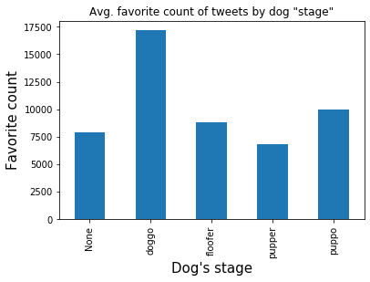

```python
# Dog_stages are ploted with favorite_count.mean
twitter_archive_clean2.groupby(['dog_stage']).favorite_count.mean().plot(kind='bar');
plt.title('Avg. favorite count of tweets by dog "stage"');
plt.ylabel('Favorite count', fontsize = 15);
plt.xlabel("Dog's stage", fontsize = 15);
```

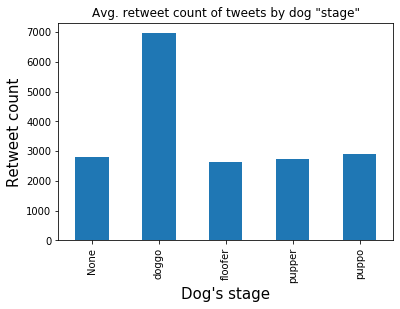

```python
# Dog_stages are ploted with favorite_count.mean
twitter_archive_clean2.groupby(['dog_stage']).retweet_count.mean().plot(kind='bar');
plt.title('Avg. retweet count of tweets by dog "stage"');
plt.ylabel('Retweet count', fontsize=15);
plt.xlabel("Dog's stage", fontsize=15);
```

##### What breeds are more common to be found?

```python
# Counts of dog breeds for algorithm 1
image_predictions_clean.prediction1.value_counts()
```

```
golden_retriever      150
Labrador_retriever    100
Pembroke               89
Chihuahua              83
pug                    57
                     ...
hotdog                  1
water_bottle            1
mud_turtle              1
otter                   1
sliding_door            1
Name: prediction1, Length: 378, dtype: int64
```

```python
# Counts of dog breeds for algorithm 2
image_predictions_clean.prediction2.value_counts()
```

```
Labrador_retriever     104
golden_retriever        92
Cardigan                73
Chihuahua               44
Pomeranian              42
                      ...
washbasin                1
medicine_chest           1
cockroach                1
African_hunting_dog      1
shopping_cart            1
Name: prediction2, Length: 405, dtype: int64
```

```python
# Counts of dog breeds for algorithm 3
image_predictions_clean.prediction3.value_counts()
```

```
Labrador_retriever    79
Chihuahua             58
golden_retriever      48
Eskimo_dog            38
kelpie                35
                      ..
rock_crab              1
affenpinscher          1
snail                  1
acorn                  1
viaduct                1
Name: prediction3, Length: 408, dtype: int64
```

> From these values it seems as if the retriever dogs are the ones being predicted the by all three algorithms. It is important to see which algorithm delivers results with higher confidence. An extra step could be checking is specific breeds have more favorited or retweets than others.

```python
# Descriptive statistics of the predictions table
image_predictions_clean.describe()
```

|  | tweet_id | img_num | prediction1_confidence | prediction2_confidence | prediction3_confidence |
| --- | --- | --- | --- | --- | --- |
| count | 2.075000e+03 | 2075.000000 | 2075.000000 | 2.075000e+03 | 2.075000e+03 |
| mean | 7.384514e+17 | 1.203855 | 0.594548 | 1.345886e-01 | 6.032417e-02 |
| std | 6.785203e+16 | 0.561875 | 0.271174 | 1.006657e-01 | 5.090593e-02 |
| min | 6.660209e+17 | 1.000000 | 0.044333 | 1.011300e-08 | 1.740170e-10 |
| 25% | 6.764835e+17 | 1.000000 | 0.364412 | 5.388625e-02 | 1.622240e-02 |
| 50% | 7.119988e+17 | 1.000000 | 0.588230 | 1.181810e-01 | 4.944380e-02 |
| 75% | 7.932034e+17 | 1.000000 | 0.843855 | 1.955655e-01 | 9.180755e-02 |
| max | 8.924206e+17 | 4.000000 | 1.000000 | 4.880140e-01 | 2.734190e-01 |

> Perhaps as expected, predictions 1 are the ones with higher confidence rates.

##### Are longer tweets favored?

```python
# In order to use the tweet_length column it had to be divided into two columns
detailed_tweets_clean[['tweet_start','tweet_end']] = pd.DataFrame(detailed_tweets_clean.tweet_length.tolist(), index= detailed_tweets_clean.index)
```

```python
# Inspect the most frequent tweet length
detailed_tweets_clean.tweet_end.mode()
```

```
0    140
dtype: int64
```

```python
# Inspect tweets length
detailed_tweets_clean.tweet_end.value_counts()
```

```
140    252
139    145
138     79
137     77
116     59
      ...
29       1
31       1
43       1
145      1
11       1
Name: tweet_end, Length: 125, dtype: int64
```

```python
# Creation of masks to categorize tweets lengths with 1/3rd of the maximum allowed as base
Long = detailed_tweets_clean.tweet_end > 50
Short= detailed_tweets_clean.tweet_end <  50
```

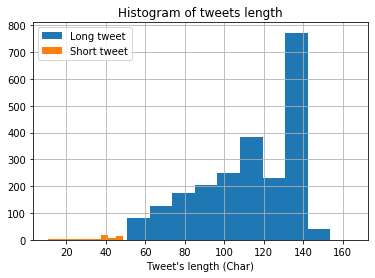

```python
# Histogram of tweets lengths
detailed_tweets_clean.tweet_end[Long].hist(label = 'Long tweet');
detailed_tweets_clean.tweet_end[Short].hist(label = 'Short tweet');
plt.title("Histogram of tweets length")
plt.xlabel("Tweet's length (Char)")
plt.legend();
```

```python
# What is the mean of favorite counts for long tweets
detailed_tweets_clean.favorite_count[Long].mean()
```

```
7504.939180255619
```

```python
# What is the mean of favorite counts for short tweets
detailed_tweets_clean.favorite_count[Short].mean()
```

```
5229.1551724137935
```

> As seen the average of favorite counts for longer tweets is higher. This makes sense as longer tweets tend to provide more info on the dog.

```python
# What is the mean of retweets for long tweets
detailed_tweets_clean.retweet_count[Long].mean()
```

```
2681.32921992067
```

```python
# What is the mean of retweets for short tweets
detailed_tweets_clean.retweet_count[Short].mean()
```

```
1487.2241379310344
```

> Similarly, the number of retweets for longer tweets is higher. One aspect to take into account is that, longer tweets are more than shorter ones. Hence further inspections of this relationship have to be done in order to stablish any relationship.

## References

1.- https://stackoverflow.com/questions/59094921/parsing-data-from-json-tweepy-into-a-pandas-dataframe/59095043#59095043

2.- https://www.shanelynn.ie/select-pandas-dataframe-rows-and-columns-using-iloc-loc-and-ix/

3.- https://www.datacamp.com/community/tutorials/python-if-elif-else?utm_source=adwords_ppc&utm_campaignid=898687156&utm_adgroupid=48947256715&utm_device=c&utm_keyword=&utm_matchtype=b&utm_network=g&utm_adpostion=&utm_creative=332602034352&utm_targetid=aud-299261629574:dsa-429603003980&utm_loc_interest_ms=&utm_loc_physical_ms=1005493&gclid=CjwKCAjwkdL6BRAREiwA-kiczFfdjsnCPxYgG-KkoTdL6yTZlgPJWhNVg2t4Rl9Liba9DNa0iKocfBoCiREQAvD_BwE

4.-https://stackoverflow.com/questions/49161120/pandas-python-set-value-of-one-column-based-on-value-in-another-column